報告講義：Model Selection & Boosting

講義作者：許喬雅

Topic1：Model Selection

# 一、交叉驗證 (Cross-validation, CV) 介紹

1. 方法：透過不同的訓練、測試資料組合，代入模型中作預測及驗證
2. 效果：提供更多數據去作驗證，作為模型選擇判斷的依據
3. 目的：衡量模型的表現、調整參數
4. 包含：
   - Resubstitution
   - Holdout CV
   - Leave-one-out CV
   - K-fold CV
1. Resubstitution (自我一致性評估法)：
   - 使用相同的資料進行訓練和測試
   - 通常只用在從Training data找參數用
   - Resubstitution error

[figure not shown]

1. Holdout CV：
   - 隨機取得 → p%資料為Training data，剩下的 (1-p)% 為Testing data
   - 會考慮資料類別
   - 最後的結果和Testing data進行成效比對 (Performance comparison)

[figure not shown]

1. Leave-one-out CV (LOOCV)：
   - 每次都將一筆資料視為Testing data，剩下的為Training data
   - 直到每一筆都被當做Testing data 為止

[figure not shown]

1. K-fold CV：
   - 將資料隨機平均分成k個集合 → 某一個集合當做Testing data，剩下的k-1個集合為Training data
   - 重複進行直到每一個集合都被當做 Testing data為止
   - 會考慮資料類別
   - K值的選擇：視資料集大小、CPU能力 (computational costs)而定
   - K值小 → 變異小、偏差大、成本低 ; K值大 → 變異大、偏差小、成本高

[figure not shown]

圖片來源：https://medium.com/@chih.sheng.huang821/%E4%BA%A4%E5%8F%89%E9%A9%97%E8%AD%89-cross-validation-cv-3b2c714b18db

## 二、K-fold CV實做

1. 設定工作路徑

```r
setwd('C:\\Users\\asus\\Documents\\大四上\\intern\\week4\\Part 10 - Model Selection _ Boosting\\Section 48 - Model Selection\\R')
```

2. 匯入原始資料

```r
dataset = read.csv('Social_Network_Ads.csv')
head(dataset, 6)
```

A data.frame: 6 × 5

|  | User.ID <int> | Gender <chr> | Age <dbl> | EstimatedSalary <dbl> | Purchased <int> |
| --- | --- | --- | --- | --- | --- |
| 1 | 15624510 | Male | 19 | 19000 | 0 |
| 2 | 15810944 | Male | 35 | 20000 | 0 |
| 3 | 15668575 | Female | 26 | 43000 | 0 |
| 4 | 15603246 | Female | 27 | 57000 | 0 |
| 5 | 15804002 | Male | 19 | 76000 | 0 |
| 6 | 15728773 | Male | 27 | 58000 | 0 |

3. 擷取所需資料

```r
dataset = dataset[3:5]
head(dataset, 6)
```

A data.frame: 6 × 3

|  | Age <dbl> | EstimatedSalary <dbl> | Purchased <int> |
| --- | --- | --- | --- |
| 1 | 19 | 19000 | 0 |
| 2 | 35 | 20000 | 0 |
| 3 | 26 | 43000 | 0 |
| 4 | 27 | 57000 | 0 |
| 5 | 19 | 76000 | 0 |
| 6 | 27 | 58000 | 0 |

4. 轉換資料型態

```r
dataset$Purchased = factor(dataset$Purchased, levels = c(0, 1))
head(dataset, 6)
```

A data.frame: 6 × 3

|  | Age <dbl> | EstimatedSalary <dbl> | Purchased <fct> |
| --- | --- | --- | --- |
| 1 | 19 | 19000 | 0 |
| 2 | 35 | 20000 | 0 |
| 3 | 26 | 43000 | 0 |
| 4 | 27 | 57000 | 0 |
| 5 | 19 | 76000 | 0 |
| 6 | 27 | 58000 | 0 |

5. 切分資料

```r
library(caTools)
set.seed(123)
split = sample.split(dataset$Purchased, SplitRatio = 0.75)
training_set = subset(dataset, split == TRUE)
test_set = subset(dataset, split == FALSE)
```

```r
print('Training Set')
head(training_set, 6)
print('Test Set')
head(test_set ,6)
```

```
[1] "Training Set"
```

A data.frame: 6 × 3

|  | Age <dbl> | EstimatedSalary <dbl> | Purchased <fct> |
| --- | --- | --- | --- |
| 1 | 19 | 19000 | 0 |
| 3 | 26 | 43000 | 0 |
| 6 | 27 | 58000 | 0 |
| 7 | 27 | 84000 | 0 |
| 8 | 32 | 150000 | 1 |
| 10 | 35 | 65000 | 0 |

```
[1] "Test Set"
```

A data.frame: 6 × 3

|  | Age <dbl> | EstimatedSalary <dbl> | Purchased <fct> |
| --- | --- | --- | --- |
| 2 | 35 | 20000 | 0 |
| 4 | 27 | 57000 | 0 |
| 5 | 19 | 76000 | 0 |
| 9 | 25 | 33000 | 0 |
| 12 | 26 | 52000 | 0 |
| 18 | 45 | 26000 | 1 |

6. 將資料導入SVM Kernel模型

```r
library(e1071)
classifier = svm(formula = Purchased ~ .,
                 data = training_set,
                 type = 'C-classification',
                 kernel = 'radial')
```

7. 預測是否購買

```r
y_pred = predict(classifier, newdata = test_set[-3])
head(y_pred, 6)
```

**2**

0

**4**

0

**5**

0

**9**

0

**12**

0

**18**

1

**Levels**:**

1. '0'

2. '1'

8. 製作混淆矩陣

```r
cm = table(test_set[, 3], y_pred)
cm
```

```
   y_pred
     0  1
  0 58  6
  1  4 32
```

K-fold CV

(1) 切分資料

```r
library(caret)
folds = createFolds(training_set$Purchased, k = 10)
folds
```

**$Fold01**

1. 11

2. 20

3. 21

4. 34

5. 39

6. 42

7. 48

8. 53

9. 66

10. 67

11. 82

12. 101

13. 110

14. 137

15. 164

16. 178

17. 197

18. 207

19. 216

20. 221

21. 224

22. 228

23. 240

24. 248

25. 262

26. 264

27. 276

28. 287

29. 288

**$Fold02**

1. 6

2. 12

3. 28

4. 37

5. 69

6. 75

7. 109

8. 111

9. 113

10. 114

11. 116

12. 129

13. 140

14. 148

15. 157

16. 160

17. 169

18. 192

19. 195

20. 202

21. 211

22. 212

23. 231

24. 232

25. 236

26. 237

27. 241

28. 257

29. 268

30. 271

31. 279

**$Fold03**

1. 8

2. 13

3. 15

4. 32

5. 50

6. 52

7. 60

8. 93

9. 103

10. 105

11. 106

12. 124

13. 144

14. 146

15. 150

16. 162

17. 168

18. 188

19. 190

20. 206

21. 223

22. 227

23. 229

24. 238

25. 244

26. 254

27. 266

28. 267

29. 278

30. 283

31. 284

**$Fold04**

1. 26

2. 31

3. 36

4. 55

5. 59

6. 81

7. 84

8. 95

9. 134

10. 136

11. 142

12. 165

13. 172

14. 174

15. 177

16. 181

17. 187

18. 193

19. 199

20. 200

21. 204

22. 214

23. 242

24. 251

25. 258

26. 265

27. 272

28. 274

29. 275

30. 299

**$Fold05**

1. 7

2. 10

3. 24

4. 43

5. 56

6. 58

7. 71

8. 80

9. 91

10. 94

11. 97

12. 100

13. 107

14. 135

15. 138

16. 149

17. 156

18. 183

19. 185

20. 189

21. 210

22. 215

23. 218

24. 222

25. 226

26. 234

27. 243

28. 260

29. 273

30. 290

**$Fold06**

1. 27

2. 33

3. 41

4. 47

5. 51

6. 86

7. 96

8. 98

9. 117

10. 127

11. 139

12. 141

13. 152

14. 153

15. 159

16. 203

17. 205

18. 208

19. 230

20. 233

21. 235

22. 245

23. 249

24. 250

25. 270

26. 277

27. 286

28. 296

29. 300

**$Fold07**

1. 5

2. 17

3. 35

4. 46

5. 49

6. 57

7. 61

8. 65

9. 73

10. 74

11. 76

12. 90

13. 126

14. 128

15. 132

16. 143

17. 145

18. 166

19. 171

20. 173

21. 191

22. 209

23. 217

24. 255

25. 261

26. 281

27. 282

28. 289

29. 292

30. 293

**$Fold08**

1. 3

2. 18

3. 29

4. 30

5. 44

6. 62

7. 64

8. 77

9. 89

10. 102

11. 104

12. 108

13. 121

14. 125

15. 130

16. 151

17. 158

18. 161

19. 170

20. 176

21. 184

22. 194

23. 196

24. 201

25. 213

26. 263

27. 280

28. 285

29. 295

30. 297

**$Fold09**

1. 1

2. 9

3. 14

4. 16

5. 22

6. 23

7. 25

8. 40

9. 45

10. 63

11. 68

12. 70

13. 78

14. 79

15. 85

16. 92

17. 118

18. 120

19. 131

20. 133

21. 155

22. 175

23. 186

24. 198

25. 219

26. 220

27. 247

28. 291

29. 294

30. 298

**$Fold10**

1. 2

2. 4

3. 19

4. 38

5. 54

6. 72

7. 83

8. 87

9. 88

10. 99

11. 112

12. 115

13. 119

14. 122

15. 123

16. 147

17. 154

18. 163

19. 167

20. 179

21. 180

22. 182

23. 225

24. 239

25. 246

26. 252

27. 253

28. 256

29. 259

30. 269

(2) 每組資料分別代入SVM Kernel模型，並輸出accuracy

```r
cv = lapply(folds, function(x) {
  training_fold = training_set[-x, ]
  test_fold = training_set[x, ]
  classifier = svm(formula = Purchased ~ .,
                   data = training_fold,
                   type = 'C-classification',
                   kernel = 'radial')
  y_pred = predict(classifier, newdata = test_fold[-3])
  cm = table(test_fold[, 3], y_pred)
  accuracy = (cm[1,1] + cm[2,2]) / (cm[1,1] + cm[2,2] + cm[1,2] + cm[2,1])
    return(accuracy)
})
cv
```

**$Fold01**

0.931034482758621

**$Fold02**

0.935483870967742

**$Fold03**

0.903225806451613

**$Fold04**

0.866666666666667

**$Fold05**

0.933333333333333

**$Fold06**

0.931034482758621

**$Fold07**

0.966666666666667

**$Fold08**

0.8

**$Fold09**

0.966666666666667

**$Fold10**

0.933333333333333

(3) 計算十個訓練的平均accuracy

```r
accuracy = mean(as.numeric(cv))
cat('Mean Accuracy = ',accuracy)
```

```
Mean Accuracy =  0.9167445
```

比較各個模型經過K-fold cv後的準確度

(1) 將每個模型製作成function

```r
LogisticRegression = function(training_fold,test_fold){
    classifier = glm(formula = Purchased ~ .,
                     family = binomial,
                     data = training_fold)
    prob_pred = predict(classifier, type = 'response', newdata = test_fold[-3])
    y_pred = ifelse(prob_pred > 0.5, 1, 0)
    cm = table(test_fold[, 3], y_pred > 0.5)
    return(cm)
}
```

```r
Knn = function(training_fold,test_fold){
    library(class)
    y_pred = knn(train = training_fold[, -3],
                 test = test_fold[, -3],
                 cl = training_fold[, 3],
                 k = 5,
                 prob = TRUE)
    cm = table(test_fold[, 3], y_pred)
    return(cm)
}
```

```r
Svm = function(training_fold,test_fold){
    library(e1071)
    classifier = svm(formula = Purchased ~ .,
                     data = training_fold,
                     type = 'C-classification',
                     kernel = 'linear')
    y_pred = predict(classifier, newdata = test_fold[-3])
    cm = table(test_fold[, 3], y_pred)
    return(cm)
}
```

```r
KernelSVM = function(training_fold,test_fold){
    library(e1071)
    classifier = svm(formula = Purchased ~ .,
                     data = training_fold,
                     type = 'C-classification',
                     kernel = 'radial')
    y_pred = predict(classifier, newdata = test_fold[-3])
    cm = table(test_fold[, 3], y_pred)
    return(cm)
}
```

```r
NaiveBayes = function(training_fold,test_fold){
    library(e1071)
    classifier = naiveBayes(x = training_fold[-3],
                            y = training_fold$Purchased)
    y_pred = predict(classifier, newdata = test_fold[-3])
    cm = table(test_fold[, 3], y_pred)
    return(cm)
}
```

```r
DecisionTree = function(training_fold,test_fold){
    library(rpart)
    classifier = rpart(formula = Purchased ~ .,
                       data = training_fold)
    y_pred = predict(classifier, newdata = test_fold[-3], type = 'class')
    cm = table(test_fold[, 3], y_pred)
    return(cm)
}
```

```r
RandomForest = function(training_fold,test_fold){
    library(randomForest)
    set.seed(123)
    classifier = randomForest(x = training_fold[-3],
                              y = training_fold$Purchased,
                              ntree = 5000)
    y_pred = predict(classifier, newdata = test_fold[-3])
    cm = table(test_fold[, 3], y_pred)
    return(cm)
}
```

(2) Accuracy公式製作成function

```r
Accuracy = function(cm){
    accuracy = (cm[1,1] + cm[2,2]) / (cm[1,1] + cm[2,2] + cm[1,2] + cm[2,1])
    return(accuracy)
}
```

(3) 將十組資料分別代入各個模型做訓練，並輸出accuracy

```r
LR = (0)
KNN = (0)
SVM = (0)
K_SVM = (0)
NB = (0)
DT = (0)
RF = (0)
```

```r
for (x in folds){
  training_fold = training_set[-x, ]
  test_fold = training_set[x, ]
  LR = append(LR,Accuracy(LogisticRegression(training_fold,test_fold)))
  KNN = append(KNN,Accuracy(Knn(training_fold,test_fold)))
  SVM = append(SVM, Accuracy(Svm(training_fold,test_fold)))
  K_SVM = append(K_SVM, Accuracy(KernelSVM(training_fold,test_fold)))
  NB = append(NB, Accuracy(NaiveBayes(training_fold,test_fold)))
  DT = append(DT, Accuracy(DecisionTree(training_fold,test_fold)))
  RF = append(RF, Accuracy(RandomForest(training_fold,test_fold)))
}
```

(4) 計算每個模型的平均accuracy

```r
score = (0)
score = append(score, (sum(LR)/10))
score = append(score, (sum(KNN)/10))
score = append(score, (sum(SVM)/10))
score = append(score, (sum(K_SVM)/10))
score = append(score, (sum(NB)/10))
score = append(score, (sum(DT)/10))
score = append(score, (sum(RF)/10))
score = score[-1]

detafuranmo = data.frame(
  Model_Name = c('LR','KNN','SVM','K-SVM','NB','DT','RF'),
  Mean = score
)
detafuranmo
```

A data.frame: 7 × 2

| Model_Name <chr> | Mean <dbl> |
| --- | --- |
| LR | 0.8435892 |
| KNN | 0.8233741 |
| SVM | 0.8371524 |
| K-SVM | 0.9167445 |
| NB | 0.8871672 |
| DT | 0.9169596 |
| RF | 0.9035187 |

## 三、Grid search 介紹

1. 目的：調整模型的參數
2. 方法：在所有候選的參數選擇中，嘗試每一種可能性，並輸出表現最好的參數
3. 壞處：成本較大
4. 其成效與數據劃分息息相關 → 搭配 Cross-validation
5. Python：sklearn – GridSearchCV()
6. 可從以下網址找到不同模型的使用方法：http://topepo.github.io/caret/available-models.html
7. 因本文使用的是SVM模型，進入網站搜尋後，可以搜尋到要使用 'svmRadialSigma' 的方法，如下圖：

[figure not shown]

## 四、Grid search 實做

1. 資料導入grid search函式

```r
library(caret)
classifier = train(form = Purchased ~ ., data = training_set, method = 'svmRadialSigma')
classifier$bestTune
```

A data.frame: 1 × 2

|  | sigma <dbl> | C <dbl> |
| --- | --- | --- |
| 6 | 0.8777899 | 1 |

2. 輸出最佳參數

A data.frame: 9 × 6

|  | sigma <dbl> | C <dbl> | Accuracy <dbl> | Kappa <dbl> | AccuracySD <dbl> | KappaSD <dbl> |
| --- | --- | --- | --- | --- | --- | --- |
| 1 | 0.1016988 | 0.25 | 0.8877929 | 0.7460217 | 0.02818760 | 0.06250466 |
| 2 | 0.1016988 | 0.50 | 0.8910959 | 0.7569357 | 0.02212225 | 0.04869506 |
| 3 | 0.1016988 | 1.00 | 0.8965484 | 0.7709202 | 0.02045570 | 0.04387616 |
| 4 | 0.8777899 | 0.25 | 0.9061491 | 0.7942191 | 0.02133333 | 0.04566809 |
| 5 | 0.8777899 | 0.50 | 0.9095259 | 0.8019651 | 0.02194101 | 0.04597903 |
| 6 | 0.8777899 | 1.00 | 0.9135185 | 0.8106312 | 0.02065885 | 0.04369808 |
| 7 | 1.6538809 | 0.25 | 0.9091125 | 0.8011850 | 0.02166704 | 0.04519663 |
| 8 | 1.6538809 | 0.50 | 0.9105616 | 0.8039252 | 0.02002572 | 0.04214634 |
| 9 | 1.6538809 | 1.00 | 0.9101745 | 0.8028304 | 0.02457279 | 0.05171546 |

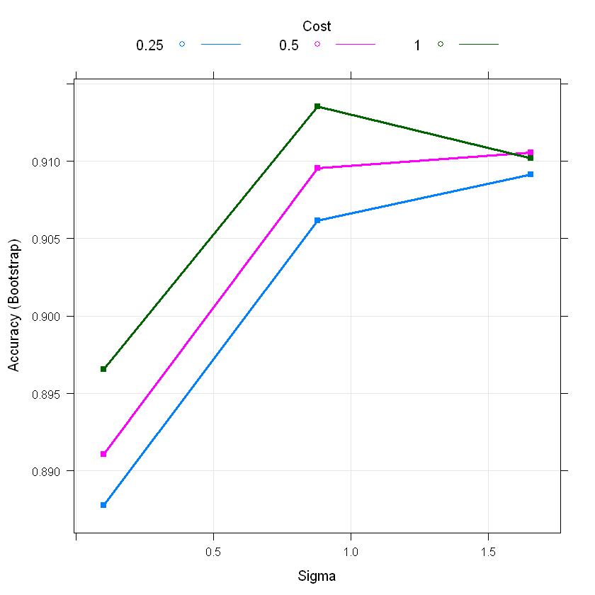

```r
classifier$results
plot(classifier, size = 6, lwd=3, pch=15)
```

```r
library(e1071)
classifier = svm(formula = Purchased ~ .,
                 data = training_set,
                 type = 'C-classification',
                 kernel = 'radial',
                 gamma = 0.8777899,
                 cost = 1)
y_pred = predict(classifier, newdata = test_set[-3])
cm = table(test_set[, 3], y_pred)
cm
accuracy = (cm[1,1] + cm[2,2]) / (cm[1,1] + cm[2,2] + cm[1,2] + cm[2,1])
cat('Accuracy = ',accuracy)
```

```
   y_pred
     0  1
  0 59  5
  1  4 32
```

```
Accuracy =  0.91
```

Topic2：Boosting

## 一、XGBoost 介紹

1. 全名：eXtreme Gradient Boosting (極限梯度提升)
2. Kaggle競賽神器 (精準度高、速度快)
3. 基本原理：
   - 基於 Tree Ensemble 模型做增量訓練 (additive training)
   - Greedy Algorithm：在樹的每層建構過程中優化目標函式
4. 重要參數→ n_estimators：代表疊代幾圈，通常數字大一點會較精確，但過多可能訓練到某幾圈就停止精確了
5. 原理：

[figure not shown]

參考網站：https://www.kdd.org/kdd2016/papers/files/rfp0697-chenAemb.pdf

## 二、XGBoost 實做

1. 設定工作路徑

```r
setwd('C:\\Users\\asus\\Documents\\大四上\\intern\\week4\\Part 10 - Model Selection _ Boosting\\Section 49 - XGBoost\\R')
```

2. 匯入原始資料

```r
dataset = read.csv('Churn_Modelling.csv')
head(dataset, 6)
```

A data.frame: 6 × 14

|  | RowNumber <int> | CustomerId <int> | Surname <chr> | CreditScore <int> | Geography <chr> | Gender <chr> | Age <int> | Tenure <int> | Balance <dbl> | NumOfProducts <int> | HasCrCard <int> | IsActiveMember <int> | EstimatedSalary <dbl> | Exited <int> |
| --- | --- | --- | --- | --- | --- | --- | --- | --- | --- | --- | --- | --- | --- | --- |
| 1 | 1 | 15634602 | Hargrave | 619 | France | Female | 42 | 2 | 0.00 | 1 | 1 | 1 | 101348.88 | 1 |
| 2 | 2 | 15647311 | Hill | 608 | Spain | Female | 41 | 1 | 83807.86 | 1 | 0 | 1 | 112542.58 | 0 |
| 3 | 3 | 15619304 | Onio | 502 | France | Female | 42 | 8 | 159660.80 | 3 | 1 | 0 | 113931.57 | 1 |
| 4 | 4 | 15701354 | Boni | 699 | France | Female | 39 | 1 | 0.00 | 2 | 0 | 0 | 93826.63 | 0 |
| 5 | 5 | 15737888 | Mitchell | 850 | Spain | Female | 43 | 2 | 125510.82 | 1 | 1 | 1 | 79084.10 | 0 |
| 6 | 6 | 15574012 | Chu | 645 | Spain | Male | 44 | 8 | 113755.78 | 2 | 1 | 0 | 149756.71 | 1 |

3. 擷取所需資料並進行資料處理

```r
dataset = dataset[4:14]
head(dataset, 6)
```

A data.frame: 6 × 11

|  | CreditScore <int> | Geography <chr> | Gender <chr> | Age <int> | Tenure <int> | Balance <dbl> | NumOfProducts <int> | HasCrCard <int> | IsActiveMember <int> | EstimatedSalary <dbl> | Exited <int> |
| --- | --- | --- | --- | --- | --- | --- | --- | --- | --- | --- | --- |
| 1 | 619 | France | Female | 42 | 2 | 0.00 | 1 | 1 | 1 | 101348.88 | 1 |
| 2 | 608 | Spain | Female | 41 | 1 | 83807.86 | 1 | 0 | 1 | 112542.58 | 0 |
| 3 | 502 | France | Female | 42 | 8 | 159660.80 | 3 | 1 | 0 | 113931.57 | 1 |
| 4 | 699 | France | Female | 39 | 1 | 0.00 | 2 | 0 | 0 | 93826.63 | 0 |
| 5 | 850 | Spain | Female | 43 | 2 | 125510.82 | 1 | 1 | 1 | 79084.10 | 0 |
| 6 | 645 | Spain | Male | 44 | 8 | 113755.78 | 2 | 1 | 0 | 149756.71 | 1 |

```r
dataset$Geography = as.numeric(factor(dataset$Geography,
                                      levels = c('France', 'Spain', 'Germany'),
                                      labels = c(1, 2, 3)))
dataset$Gender = as.numeric(factor(dataset$Gender,
                                   levels = c('Female', 'Male'),
                                   labels = c(1, 2)))
head(dataset, 6)
```

A data.frame: 6 × 11

|  | CreditScore <int> | Geography <dbl> | Gender <dbl> | Age <int> | Tenure <int> | Balance <dbl> | NumOfProducts <int> | HasCrCard <int> | IsActiveMember <int> | EstimatedSalary <dbl> | Exited <int> |
| --- | --- | --- | --- | --- | --- | --- | --- | --- | --- | --- | --- |
| 1 | 619 | 1 | 1 | 42 | 2 | 0.00 | 1 | 1 | 1 | 101348.88 | 1 |
| 2 | 608 | 2 | 1 | 41 | 1 | 83807.86 | 1 | 0 | 1 | 112542.58 | 0 |
| 3 | 502 | 1 | 1 | 42 | 8 | 159660.80 | 3 | 1 | 0 | 113931.57 | 1 |
| 4 | 699 | 1 | 1 | 39 | 1 | 0.00 | 2 | 0 | 0 | 93826.63 | 0 |
| 5 | 850 | 2 | 1 | 43 | 2 | 125510.82 | 1 | 1 | 1 | 79084.10 | 0 |
| 6 | 645 | 2 | 2 | 44 | 8 | 113755.78 | 2 | 1 | 0 | 149756.71 | 1 |

4. 切分資料

```r
library(caTools)
set.seed(123)
split = sample.split(dataset$Exited, SplitRatio = 0.8)
training_set = subset(dataset, split == TRUE)
test_set = subset(dataset, split == FALSE)
```

5. 將資料導入xgboost模型

```r
library(xgboost)
classifier = xgboost(data = as.matrix(training_set[-11]), label = training_set$Exited, nrounds = 10)
```

6. 資料預測

```r
y_pred = predict(classifier, newdata = as.matrix(test_set[-11]))
y_pred = (y_pred >= 0.5)
```

7. 製作混淆矩陣

```r
cm = table(test_set[, 11], y_pred)
cm
```

```
   y_pred
    FALSE TRUE
  0  1541   52
  1   211  196
```

8. 資料導入K-fold cv與xgboost模型

```r
library(caret)
folds = createFolds(training_set$Exited, k = 10)
cv = lapply(folds, function(x) {
  training_fold = training_set[-x, ]
  test_fold = training_set[x, ]
  classifier = xgboost(data = as.matrix(training_fold[-11]), label = training_fold$Exited, nrounds = 10)
  y_pred = predict(classifier, newdata = as.matrix(test_fold[-11]))
  y_pred = (y_pred >= 0.5)
  cm = table(test_fold[, 11], y_pred)
  accuracy = (cm[1,1] + cm[2,2]) / (cm[1,1] + cm[2,2] + cm[1,2] + cm[2,1])
  return(accuracy)
})
```

9. 計算十個訓練的平均accuracy

```r
accuracy = mean(as.numeric(cv))
cat('Accuracy = ',accuracy)
```

```
Accuracy =  0.856375
```

10. 特徵變數的重要性分析

```r
importance_matrix = xgb.importance(classifier$feature_names, model = classifier)
importance_matrix
```

A data.table: 10 × 4

| Feature <chr> | Gain <dbl> | Cover <dbl> | Frequency <dbl> |
| --- | --- | --- | --- |
| Age | 0.364498858 | 0.230360188 | 0.16835700 |
| NumOfProducts | 0.259157189 | 0.225491321 | 0.10547667 |
| IsActiveMember | 0.111628948 | 0.070413864 | 0.03651116 |
| Balance | 0.103513889 | 0.135537297 | 0.20081136 |
| Geography | 0.049673210 | 0.052545355 | 0.05882353 |
| CreditScore | 0.039918030 | 0.128646171 | 0.16227181 |
| EstimatedSalary | 0.034394649 | 0.061160305 | 0.13387424 |
| Tenure | 0.019073944 | 0.022503637 | 0.08722110 |
| Gender | 0.015631908 | 0.069107430 | 0.03245436 |
| HasCrCard | 0.002509376 | 0.004234432 | 0.01419878 |

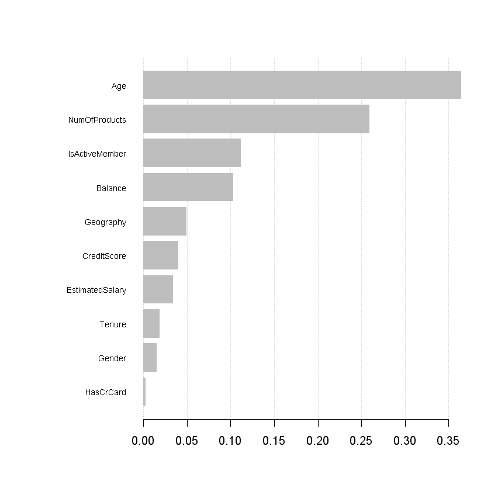

```r
xgb.plot.importance(importance_matrix[1:10,])
```

11. 成果製圖

```r
library(DiagrammeR)
xgb.plot.tree(feature_names = classifier$feature_names, model = classifier, trees = 9)
```

[interactive chart not shown]